# Metabarcoding Analysis

# Setup

```r
library(tidyverse)
library(vegan)
library(RAM)
library(lmtest)
library(car)
library(coefplot)
```

## data

Create a directory called `Data` inside of your working directory. Then copy these files into your Data folder:

- BioDatFull2.csv
- mapping_file.csv
- 97_OTU_table_QIIME1.txt

```r
BioDatFull <- read.csv("./Data/BioDatFull2.csv")
Mapping_file <- read.csv("./Data/mapping_file.csv",fileEncoding="UTF-8-BOM")
OTU_table <- read.delim("./Data/97_OTU_table_QIIME1.txt", header=T)
names(Mapping_file)
```

```
## [1] "SampleID" "Species"  "tissue"
```

We need to rearrange the OTU table. Think of this table exactly as you did the floristic survey!

We want the species names at the top, and the sites are analogous to the samples (SRR…).

```r
row.names(OTU_table)<-OTU_table$OTU_ID
OTU_table$OTU_ID<-NULL

OTU_table.nz<-OTU_table[rowSums(OTU_table[,c(1:(length(OTU_table)-1))])!=0,]
OTU_table.ns<-OTU_table.nz[rowSums(OTU_table.nz[,c(1:(length(OTU_table.nz)-1))])!=1,] # We want to remove singletons because they are likely to be errors, especially in such a large dataset.
dim(OTU_table)
```

```
## [1] 21201   178
```

```r
dim(OTU_table.ns)
```

```
## [1] 17245   178
```

```r
OTU_table<-OTU_table.ns

OTU_table.t<-transpose.OTU(OTU_table)

which( colSums(OTU_table.t)==0 )
```

```
## named integer(0)
```

```r
which( rowSums(OTU_table.t)==0 )
```

```
## named integer(0)
```

# Analysis

## Species alpha diversity model

### Calculate

```r
OTUmapping<-data.frame(SampleID=rownames(OTU_table.t))
row.names(OTUmapping)<-rownames(OTU_table.t)

OTUmapping$Richness<-rowSums(OTU_table.t!=0)
OTUmapping$Shannon<-diversity(OTU_table.t, index = "shannon", MARGIN = 1, base = exp(1))

Mapping_file$Species<-as.character(Mapping_file$Species)
Mapping_file$SampleID<-as.character(Mapping_file$SampleID)
OTUmapping$SampleID<-as.character(OTUmapping$SampleID)
for(i in 1:(length(row.names(OTUmapping)))){
OTUmapping$Species[i]<-Mapping_file[Mapping_file$SampleID==OTUmapping$SampleID[i],]$Species
}
```

Unlike before, the “site” information is not attached to the file, its in a seperate CSV.

We have two types of information: climatic info for each species (BioDatFull), and then species for each sample (Mapping_file). Now we also have our Richness and diversity information (OTU.info). We need to merge all of this and make just one dataset with the richness per species and the location/ climatic information.

```r
OTUmapping %>% group_by(Species) %>% dplyr::summarise(mean.Richness=mean(Richness),mean.Shannon=mean(Shannon)) -> OTU.info
OTU.info<-merge(OTU.info, BioDatFull, by="Species")
OTU.info$Species<-as.factor(OTU.info$Species)
MyData<-OTU.info
```

Now we model this.

STEP 1. Fit the response data to a known distribution

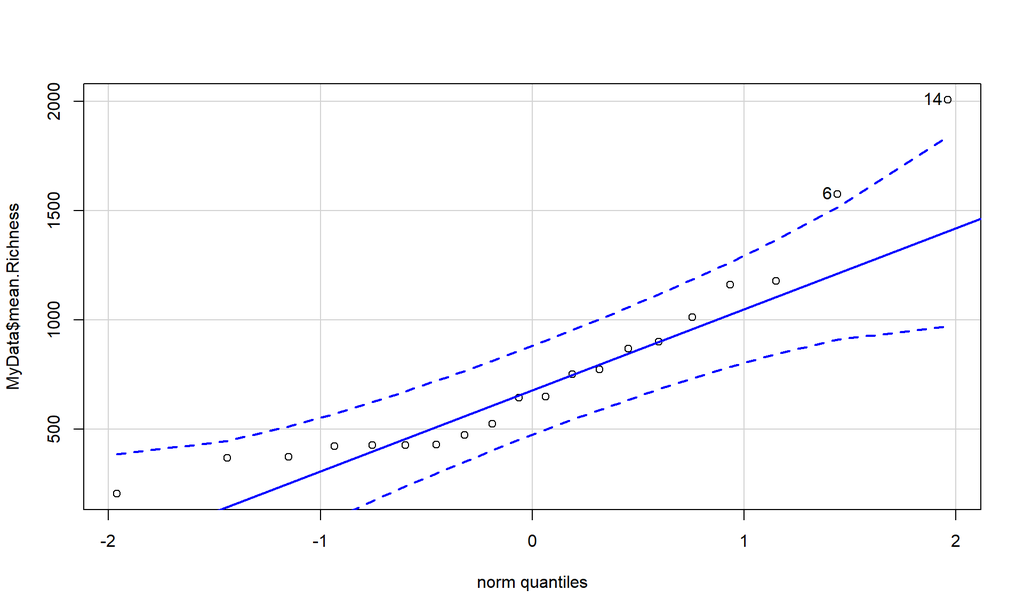

```
## [1] 14  6
```

```r
mod1<-lm(mean.Richness~ Lat + Long + Annual.mean.temperature.C + Max.temperature.C+ Min.temperature.C + Temperature.annual.range.C+ Annual.precipitation.mm. + Precipitation.seasonality.C.of.V.+ Annual.mean.moisture.index + Highest.weekly.moisture.index+ Lowest.weekly.moisture.index+ Moisture.index.seasonality.C.of.V., data = MyData)

car::qqp(MyData$mean.Richness, "norm")
```

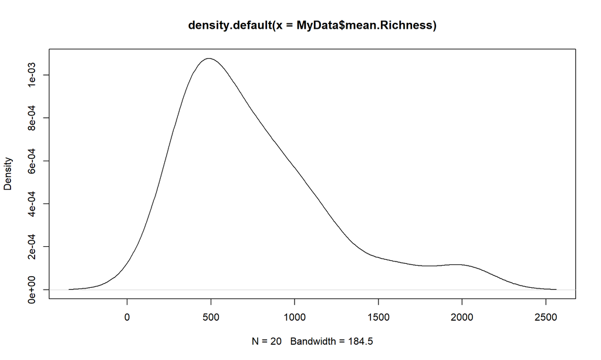

```r
plot(density(MyData$mean.Richness)) # does it fit a normal distribution?
```

```r
shapiro.test(MyData$mean.Richness)
```

```
##
##  Shapiro-Wilk normality test
##
## data:  MyData$mean.Richness
## W = 0.87353, p-value = 0.01356
```

```r
bptest(mod1) # are the residuals homoskedastic?
```

```
##
##  studentized Breusch-Pagan test
##
## data:  mod1
## BP = 13.179, df = 11, p-value = 0.2818
```

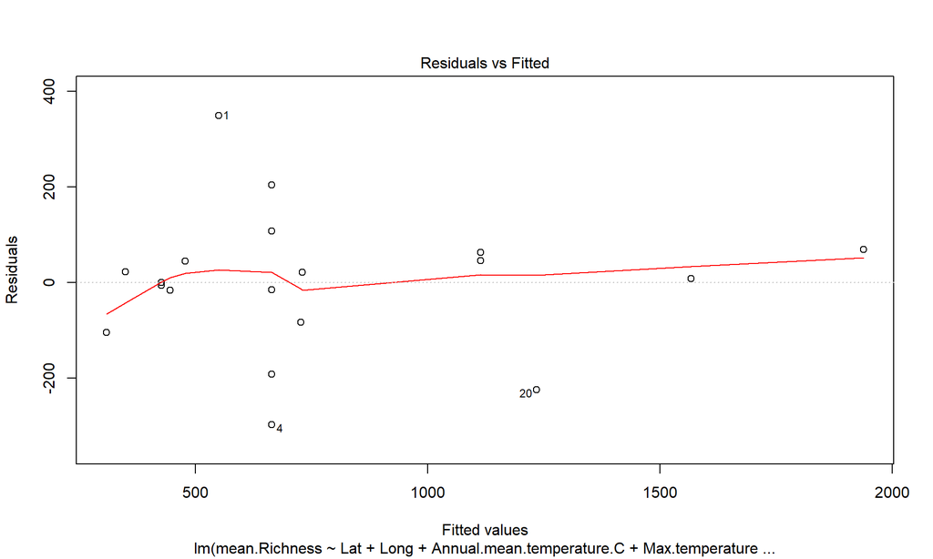

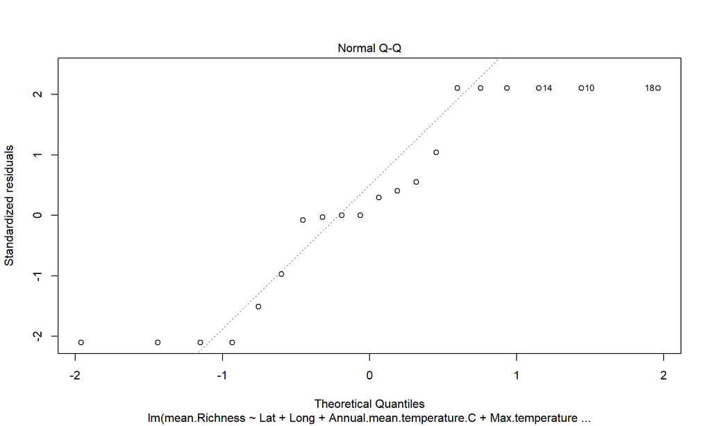

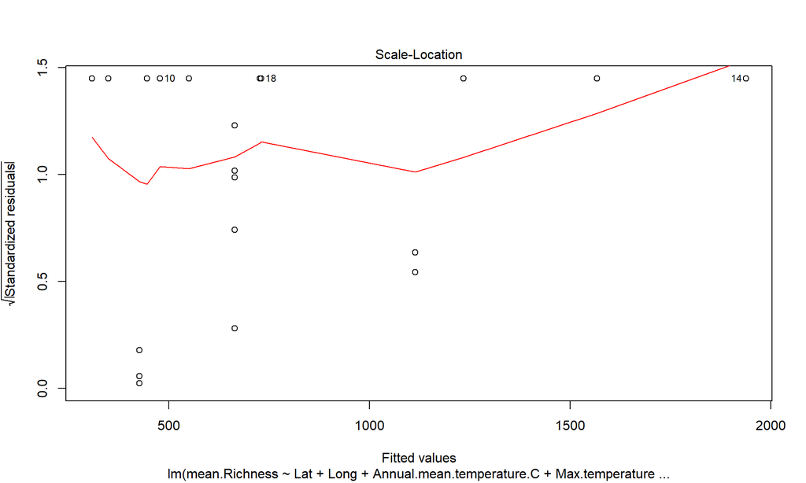

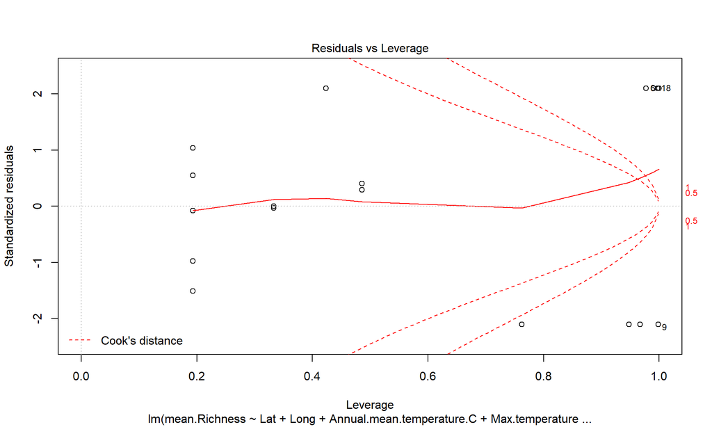

```r
plot(mod1) # visual check
```

STEP 2. Likelihood ratio test (test parameters)

To test each parameter, remove it and see if the model is as ‘likely’ without it.

```r
mod1.mLat<-update(mod1,.~. - Lat)
anova(mod1,mod1.mLat)
```

```
## Analysis of Variance Table
##
## Model 1: mean.Richness ~ Lat + Long + Annual.mean.temperature.C + Max.temperature.C +
##     Min.temperature.C + Temperature.annual.range.C + Annual.precipitation.mm. +
##     Precipitation.seasonality.C.of.V. + Annual.mean.moisture.index +
##     Highest.weekly.moisture.index + Lowest.weekly.moisture.index +
##     Moisture.index.seasonality.C.of.V.
## Model 2: mean.Richness ~ Long + Annual.mean.temperature.C + Max.temperature.C +
##     Min.temperature.C + Temperature.annual.range.C + Annual.precipitation.mm. +
##     Precipitation.seasonality.C.of.V. + Annual.mean.moisture.index +
##     Highest.weekly.moisture.index + Lowest.weekly.moisture.index +
##     Moisture.index.seasonality.C.of.V.
##   Res.Df     RSS Df Sum of Sq      F   Pr(>F)
## 1      8  382897
## 2      9 1404413 -1  -1021516 21.343 0.001711 **
## ---
## Signif. codes:  0 '***' 0.001 '**' 0.01 '*' 0.05 '.' 0.1 ' ' 1
```

```r
mod1.mLong<-update(mod1,.~. - Long)
anova(mod1,mod1.mLong)
```

```
## Analysis of Variance Table
##
## Model 1: mean.Richness ~ Lat + Long + Annual.mean.temperature.C + Max.temperature.C +
##     Min.temperature.C + Temperature.annual.range.C + Annual.precipitation.mm. +
##     Precipitation.seasonality.C.of.V. + Annual.mean.moisture.index +
##     Highest.weekly.moisture.index + Lowest.weekly.moisture.index +
##     Moisture.index.seasonality.C.of.V.
## Model 2: mean.Richness ~ Lat + Annual.mean.temperature.C + Max.temperature.C +
##     Min.temperature.C + Temperature.annual.range.C + Annual.precipitation.mm. +
##     Precipitation.seasonality.C.of.V. + Annual.mean.moisture.index +
##     Highest.weekly.moisture.index + Lowest.weekly.moisture.index +
##     Moisture.index.seasonality.C.of.V.
##   Res.Df     RSS Df Sum of Sq     F   Pr(>F)
## 1      8  382897
## 2      9 1188407 -1   -805510 16.83 0.003426 **
## ---
## Signif. codes:  0 '***' 0.001 '**' 0.01 '*' 0.05 '.' 0.1 ' ' 1
```

```r
mod1.mAnnual.mean.temperature.C<-update(mod1,.~. - Annual.mean.temperature.C)
anova(mod1,mod1.mAnnual.mean.temperature.C)
```

```
## Analysis of Variance Table
##
## Model 1: mean.Richness ~ Lat + Long + Annual.mean.temperature.C + Max.temperature.C +
##     Min.temperature.C + Temperature.annual.range.C + Annual.precipitation.mm. +
##     Precipitation.seasonality.C.of.V. + Annual.mean.moisture.index +
##     Highest.weekly.moisture.index + Lowest.weekly.moisture.index +
##     Moisture.index.seasonality.C.of.V.
## Model 2: mean.Richness ~ Lat + Long + Max.temperature.C + Min.temperature.C +
##     Temperature.annual.range.C + Annual.precipitation.mm. + Precipitation.seasonality.C.of.V. +
##     Annual.mean.moisture.index + Highest.weekly.moisture.index +
##     Lowest.weekly.moisture.index + Moisture.index.seasonality.C.of.V.
##   Res.Df     RSS Df Sum of Sq      F   Pr(>F)
## 1      8  382897
## 2      9 1523500 -1  -1140603 23.831 0.001222 **
## ---
## Signif. codes:  0 '***' 0.001 '**' 0.01 '*' 0.05 '.' 0.1 ' ' 1
```

```r
mod1.mMin.temperature.C<-update(mod1,.~. - Min.temperature.C)
anova(mod1,mod1.mMin.temperature.C)
```

```
## Analysis of Variance Table
##
## Model 1: mean.Richness ~ Lat + Long + Annual.mean.temperature.C + Max.temperature.C +
##     Min.temperature.C + Temperature.annual.range.C + Annual.precipitation.mm. +
##     Precipitation.seasonality.C.of.V. + Annual.mean.moisture.index +
##     Highest.weekly.moisture.index + Lowest.weekly.moisture.index +
##     Moisture.index.seasonality.C.of.V.
## Model 2: mean.Richness ~ Lat + Long + Annual.mean.temperature.C + Max.temperature.C +
##     Temperature.annual.range.C + Annual.precipitation.mm. + Precipitation.seasonality.C.of.V. +
##     Annual.mean.moisture.index + Highest.weekly.moisture.index +
##     Lowest.weekly.moisture.index + Moisture.index.seasonality.C.of.V.
##   Res.Df    RSS Df Sum of Sq F Pr(>F)
## 1      8 382897
## 2      8 382897  0   0.30859
```

```r
mod1.mTemperature.annual.range.C<-update(mod1.mMin.temperature.C,.~. - Temperature.annual.range.C)
anova(mod1.mMin.temperature.C,mod1.mTemperature.annual.range.C)
```

```
## Analysis of Variance Table
##
## Model 1: mean.Richness ~ Lat + Long + Annual.mean.temperature.C + Max.temperature.C +
##     Temperature.annual.range.C + Annual.precipitation.mm. + Precipitation.seasonality.C.of.V. +
##     Annual.mean.moisture.index + Highest.weekly.moisture.index +
##     Lowest.weekly.moisture.index + Moisture.index.seasonality.C.of.V.
## Model 2: mean.Richness ~ Lat + Long + Annual.mean.temperature.C + Max.temperature.C +
##     Annual.precipitation.mm. + Precipitation.seasonality.C.of.V. +
##     Annual.mean.moisture.index + Highest.weekly.moisture.index +
##     Lowest.weekly.moisture.index + Moisture.index.seasonality.C.of.V.
##   Res.Df     RSS Df Sum of Sq      F    Pr(>F)
## 1      8  382897
## 2      9 1647688 -1  -1264791 26.426 0.0008845 ***
## ---
## Signif. codes:  0 '***' 0.001 '**' 0.01 '*' 0.05 '.' 0.1 ' ' 1
```

```r
mod1.mAnnual.precipitation.mm.<-update(mod1.mMin.temperature.C,.~. - Annual.precipitation.mm.)
anova(mod1.mMin.temperature.C,mod1.mAnnual.precipitation.mm.)
```

```
## Analysis of Variance Table
##
## Model 1: mean.Richness ~ Lat + Long + Annual.mean.temperature.C + Max.temperature.C +
##     Temperature.annual.range.C + Annual.precipitation.mm. + Precipitation.seasonality.C.of.V. +
##     Annual.mean.moisture.index + Highest.weekly.moisture.index +
##     Lowest.weekly.moisture.index + Moisture.index.seasonality.C.of.V.
## Model 2: mean.Richness ~ Lat + Long + Annual.mean.temperature.C + Max.temperature.C +
##     Temperature.annual.range.C + Precipitation.seasonality.C.of.V. +
##     Annual.mean.moisture.index + Highest.weekly.moisture.index +
##     Lowest.weekly.moisture.index + Moisture.index.seasonality.C.of.V.
##   Res.Df     RSS Df Sum of Sq      F    Pr(>F)
## 1      8  382897
## 2      9 1604861 -1  -1221964 25.531 0.0009858 ***
## ---
## Signif. codes:  0 '***' 0.001 '**' 0.01 '*' 0.05 '.' 0.1 ' ' 1
```

```r
mod1.mPrecipitation.seasonality.C.of.V.<-update(mod1.mMin.temperature.C,.~. - Precipitation.seasonality.C.of.V.)
anova(mod1.mMin.temperature.C,mod1.mPrecipitation.seasonality.C.of.V.)
```

```
## Analysis of Variance Table
##
## Model 1: mean.Richness ~ Lat + Long + Annual.mean.temperature.C + Max.temperature.C +
##     Temperature.annual.range.C + Annual.precipitation.mm. + Precipitation.seasonality.C.of.V. +
##     Annual.mean.moisture.index + Highest.weekly.moisture.index +
##     Lowest.weekly.moisture.index + Moisture.index.seasonality.C.of.V.
## Model 2: mean.Richness ~ Lat + Long + Annual.mean.temperature.C + Max.temperature.C +
##     Temperature.annual.range.C + Annual.precipitation.mm. + Annual.mean.moisture.index +
##     Highest.weekly.moisture.index + Lowest.weekly.moisture.index +
##     Moisture.index.seasonality.C.of.V.
##   Res.Df    RSS Df Sum of Sq      F  Pr(>F)
## 1      8 382897
## 2      9 847656 -1   -464759 9.7104 0.01431 *
## ---
## Signif. codes:  0 '***' 0.001 '**' 0.01 '*' 0.05 '.' 0.1 ' ' 1
```

```r
mod1.mAnnual.mean.moisture.index<-update(mod1.mMin.temperature.C,.~. - Annual.mean.moisture.index)
anova(mod1.mMin.temperature.C,mod1.mAnnual.mean.moisture.index)
```

```
## Analysis of Variance Table
##
## Model 1: mean.Richness ~ Lat + Long + Annual.mean.temperature.C + Max.temperature.C +
##     Temperature.annual.range.C + Annual.precipitation.mm. + Precipitation.seasonality.C.of.V. +
##     Annual.mean.moisture.index + Highest.weekly.moisture.index +
##     Lowest.weekly.moisture.index + Moisture.index.seasonality.C.of.V.
## Model 2: mean.Richness ~ Lat + Long + Annual.mean.temperature.C + Max.temperature.C +
##     Temperature.annual.range.C + Annual.precipitation.mm. + Precipitation.seasonality.C.of.V. +
##     Highest.weekly.moisture.index + Lowest.weekly.moisture.index +
##     Moisture.index.seasonality.C.of.V.
##   Res.Df    RSS Df Sum of Sq      F Pr(>F)
## 1      8 382897
## 2      9 457517 -1    -74620 1.5591 0.2471
```

```r
mod1.mHighest.weekly.moisture.index<-update(mod1.mAnnual.mean.moisture.index,.~. - Highest.weekly.moisture.index)
anova(mod1.mAnnual.mean.moisture.index,mod1.mHighest.weekly.moisture.index)
```

```
## Analysis of Variance Table
##
## Model 1: mean.Richness ~ Lat + Long + Annual.mean.temperature.C + Max.temperature.C +
##     Temperature.annual.range.C + Annual.precipitation.mm. + Precipitation.seasonality.C.of.V. +
##     Highest.weekly.moisture.index + Lowest.weekly.moisture.index +
##     Moisture.index.seasonality.C.of.V.
## Model 2: mean.Richness ~ Lat + Long + Annual.mean.temperature.C + Max.temperature.C +
##     Temperature.annual.range.C + Annual.precipitation.mm. + Precipitation.seasonality.C.of.V. +
##     Lowest.weekly.moisture.index + Moisture.index.seasonality.C.of.V.
##   Res.Df     RSS Df Sum of Sq     F    Pr(>F)
## 1      9  457517
## 2     10 2406534 -1  -1949017 38.34 0.0001604 ***
## ---
## Signif. codes:  0 '***' 0.001 '**' 0.01 '*' 0.05 '.' 0.1 ' ' 1
```

```r
mod1.mLowest.weekly.moisture.index<-update(mod1.mAnnual.mean.moisture.index,.~. - Lowest.weekly.moisture.index)
anova(mod1.mAnnual.mean.moisture.index,mod1.mLowest.weekly.moisture.index)
```

```
## Analysis of Variance Table
##
## Model 1: mean.Richness ~ Lat + Long + Annual.mean.temperature.C + Max.temperature.C +
##     Temperature.annual.range.C + Annual.precipitation.mm. + Precipitation.seasonality.C.of.V. +
##     Highest.weekly.moisture.index + Lowest.weekly.moisture.index +
##     Moisture.index.seasonality.C.of.V.
## Model 2: mean.Richness ~ Lat + Long + Annual.mean.temperature.C + Max.temperature.C +
##     Temperature.annual.range.C + Annual.precipitation.mm. + Precipitation.seasonality.C.of.V. +
##     Highest.weekly.moisture.index + Moisture.index.seasonality.C.of.V.
##   Res.Df    RSS Df Sum of Sq      F  Pr(>F)
## 1      9 457517
## 2     10 784160 -1   -326643 6.4255 0.03198 *
## ---
## Signif. codes:  0 '***' 0.001 '**' 0.01 '*' 0.05 '.' 0.1 ' ' 1
```

```r
mod1.mMoisture.index.seasonality.C.of.V<-update(mod1.mAnnual.mean.moisture.index,.~. - Moisture.index.seasonality.C.of.V.)
anova(mod1.mAnnual.mean.moisture.index,mod1.mMoisture.index.seasonality.C.of.V)
```

```
## Analysis of Variance Table
##
## Model 1: mean.Richness ~ Lat + Long + Annual.mean.temperature.C + Max.temperature.C +
##     Temperature.annual.range.C + Annual.precipitation.mm. + Precipitation.seasonality.C.of.V. +
##     Highest.weekly.moisture.index + Lowest.weekly.moisture.index +
##     Moisture.index.seasonality.C.of.V.
## Model 2: mean.Richness ~ Lat + Long + Annual.mean.temperature.C + Max.temperature.C +
##     Temperature.annual.range.C + Annual.precipitation.mm. + Precipitation.seasonality.C.of.V. +
##     Highest.weekly.moisture.index + Lowest.weekly.moisture.index
##   Res.Df     RSS Df Sum of Sq      F    Pr(>F)
## 1      9  457517
## 2     10 2227734 -1  -1770216 34.823 0.0002288 ***
## ---
## Signif. codes:  0 '***' 0.001 '**' 0.01 '*' 0.05 '.' 0.1 ' ' 1
```

```r
mod1<-mod1.mAnnual.mean.moisture.index
summary(mod1) # this is not done to look at the "stars" but rather to look at the Estimate value.
```

```
##
## Call:
## lm(formula = mean.Richness ~ Lat + Long + Annual.mean.temperature.C +
##     Max.temperature.C + Temperature.annual.range.C + Annual.precipitation.mm. +
##     Precipitation.seasonality.C.of.V. + Highest.weekly.moisture.index +
##     Lowest.weekly.moisture.index + Moisture.index.seasonality.C.of.V.,
##     data = MyData)
##
## Residuals:
##     Min      1Q  Median      3Q     Max
## -302.22  -37.66  -16.63   81.21  380.56
##
## Coefficients:
##                                      Estimate Std. Error t value Pr(>|t|)
## (Intercept)                          -870.448   1015.544  -0.857 0.413617
## Lat                                  -114.383     19.504  -5.865 0.000239
## Long                                   -9.509      2.410  -3.946 0.003376
## Annual.mean.temperature.C           -2883.019    465.207  -6.197 0.000159
## Max.temperature.C                    2465.422    402.822   6.120 0.000175
## Temperature.annual.range.C           -781.639    127.073  -6.151 0.000168
## Annual.precipitation.mm.               26.389      4.306   6.129 0.000173
## Precipitation.seasonality.C.of.V.   -3781.997   1245.390  -3.037 0.014091
## Highest.weekly.moisture.index      -37602.814   6072.885  -6.192 0.000160
## Lowest.weekly.moisture.index        -1846.175    728.314  -2.535 0.031979
## Moisture.index.seasonality.C.of.V.  47241.777   8005.632   5.901 0.000229
##
## (Intercept)
## Lat                                ***
## Long                               **
## Annual.mean.temperature.C          ***
## Max.temperature.C                  ***
## Temperature.annual.range.C         ***
## Annual.precipitation.mm.           ***
## Precipitation.seasonality.C.of.V.  *
## Highest.weekly.moisture.index      ***
## Lowest.weekly.moisture.index       *
## Moisture.index.seasonality.C.of.V. ***
## ---
## Signif. codes:  0 '***' 0.001 '**' 0.01 '*' 0.05 '.' 0.1 ' ' 1
##
## Residual standard error: 225.5 on 9 degrees of freedom
## Multiple R-squared:  0.8818, Adjusted R-squared:  0.7505
## F-statistic: 6.716 on 10 and 9 DF,  p-value: 0.004249
```

### Visualize

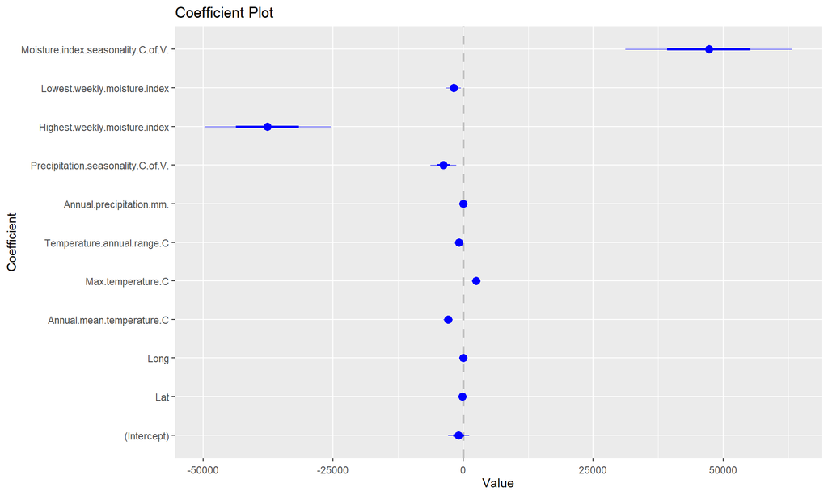

```r
coefplot(mod1)
```

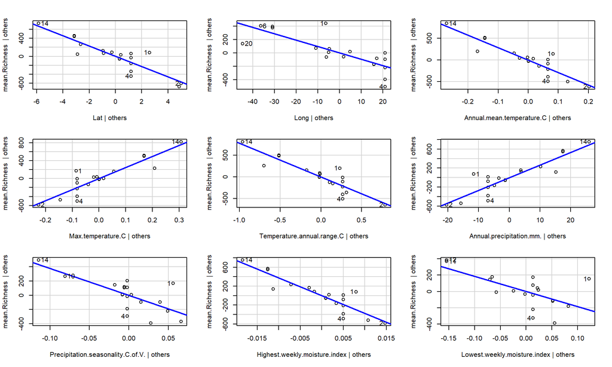

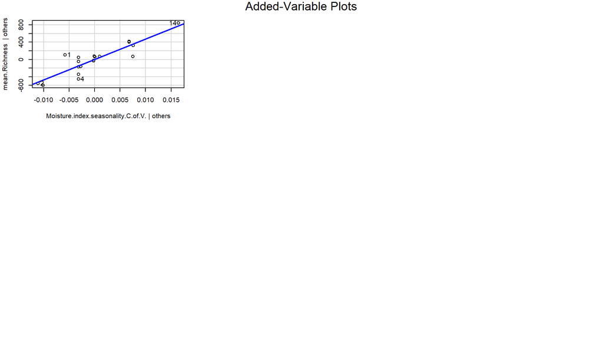

```r
avPlots(mod1)
```

## Redundancy analysis: a multivariate linear model

### Calculate

We have the same problem here with the samples having no specific data but rather we have experiement specific characteristics. We need to average them out then.

```r
X<-OTUmapping[,c(1,4)]
OTU_table.t$SampleID<-row.names(OTU_table.t)
OTU_table.t_species<-merge(OTU_table.t,X, by="SampleID",all = T)
OTU_table.t_species$SampleID<-NULL


OTU_table.tX<-aggregate(OTU_table.t_species, by = list(Species=OTU_table.t_species$Species), FUN=mean)
rownames(OTU_table.tX)<-OTU_table.tX$Species
OTU_table.tX$Species<-NULL
OTU_table.tX$Species<-NULL
OTU_table.hell <- decostand(OTU_table.tX, "hell")
```

Now we do the RDA:

```r
var <-MyData[,c(4:15)] # Isolate my variables to make this whole code easier to read

formulaRDA<- rda(OTU_table.hell ~ ., data=var, scale=T) # notice my predictive variable are being scaled too.

head(summary(formulaRDA))
```

```
##
## Call:
## rda(formula = OTU_table.hell ~ Lat + Long + Annual.mean.temperature.C +      Max.temperature.C + Min.temperature.C + Temperature.annual.range.C +      Annual.precipitation.mm. + Precipitation.seasonality.C.of.V. +      Annual.mean.moisture.index + Highest.weekly.moisture.index +      Lowest.weekl…
##
## Partitioning of correlations:
##               Inertia Proportion
## Total           17245     1.0000
## Constrained     11678     0.6772
## Unconstrained    5567     0.3228
##
## Eigenvalues, and their contribution to the correlations
##
## Importance of components:
##                           RDA1      RDA2      RDA3      RDA4      RDA5
## Eigenvalue            2327.930 1975.9423 1763.1408 1.255e+03 1.221e+03
## Proportion Explained     0.135    0.1146    0.1022 7.279e-02 7.078e-02
## Cumulative Proportion    0.135    0.2496    0.3518 4.246e-01 4.954e-01
##                            RDA6     RDA7      RDA8      RDA9     RDA10
## Eigenvalue            788.44555 727.6898 640.65842 392.72631 354.84682
## Proportion Explained    0.04572   0.0422   0.03715   0.02277   0.02058
## Cumulative Proportion   0.54110   0.5833   0.62045   0.64322   0.66380
##                           RDA11       PC1       PC2       PC3       PC4
## Eigenvalue            230.68745 2020.2116 1.578e+03 592.13703 487.21018
## Proportion Explained    0.01338    0.1171 9.149e-02   0.03434   0.02825
## Cumulative Proportion   0.67718    0.7943 8.858e-01   0.92015   0.94840
##                             PC5       PC6       PC7       PC8
## Eigenvalue            350.63881 254.17974 1.498e+02 1.352e+02
## Proportion Explained    0.02033   0.01474 8.685e-03 7.839e-03
## Cumulative Proportion   0.96874   0.98348 9.922e-01 1.000e+00
##
## Accumulated constrained eigenvalues
## Importance of components:
##                            RDA1      RDA2      RDA3      RDA4      RDA5
## Eigenvalue            2327.9302 1975.9423 1763.1408 1255.2038 1220.6500
## Proportion Explained     0.1993    0.1692    0.1510    0.1075    0.1045
## Cumulative Proportion    0.1993    0.3685    0.5195    0.6270    0.7315
##                            RDA6      RDA7      RDA8      RDA9     RDA10
## Eigenvalue            788.44555 727.68980 640.65842 392.72631 354.84682
## Proportion Explained    0.06752   0.06231   0.05486   0.03363   0.03039
## Cumulative Proportion   0.79906   0.86137   0.91623   0.94986   0.98025
```

[output cut: 58 more lines]

```
## Highest.weekly.moisture.index      -0.31729  0.18520  0.06817  0.08945
## Lowest.weekly.moisture.index       -0.17952  0.40587 -0.20965 -0.14140
## Moisture.index.seasonality.C.of.V. -0.08482 -0.48564  0.14857  0.29684
##                                        RDA5      RDA6
## Lat                                 0.22696  0.104460
## Long                               -0.32993  0.012740
## Annual.mean.temperature.C          -0.29649 -0.018128
## Max.temperature.C                  -0.15561 -0.082129
## Min.temperature.C                  -0.24543  0.004117
## Annual.precipitation.mm.           -0.22776  0.211486
## Precipitation.seasonality.C.of.V.  -0.21315 -0.093221
## Annual.mean.moisture.index         -0.08738  0.238996
## Highest.weekly.moisture.index      -0.15837  0.133139
## Lowest.weekly.moisture.index       -0.05741  0.209658
## Moisture.index.seasonality.C.of.V. -0.07581 -0.205038
```

```r
RsquareAdj(formulaRDA)
```

```
## $r.squared
## [1] 0.6771772
##
## $adj.r.squared
## [1] 0.2332959
```

```r
anova(formulaRDA, permutations=1000) # Is the RDA meaningful?
```

```
## Permutation test for rda under reduced model
## Permutation: free
## Number of permutations: 1000
##
## Model: rda(formula = OTU_table.hell ~ Lat + Long + Annual.mean.temperature.C + Max.temperature.C + Min.temperature.C + Temperature.annual.range.C + Annual.precipitation.mm. + Precipitation.seasonality.C.of.V. + Annual.mean.moisture.index + Highest.weekly.moisture.index + Lowest.weekly.moisture.in…
##          Df Variance      F  Pr(>F)
## Model    11  11677.9 1.5256 0.07992 .
## Residual  8   5567.1
## ---
## Signif. codes:  0 '***' 0.001 '**' 0.01 '*' 0.05 '.' 0.1 ' ' 1
```

```r
anova.cca(formulaRDA, by="margin", permutations=1000) # If so, are any predictor variables meaningful?
```

```
## Permutation test for rda under reduced model
## Marginal effects of terms
## Permutation: free
## Number of permutations: 1000
##
## Model: rda(formula = OTU_table.hell ~ Lat + Long + Annual.mean.temperature.C + Max.temperature.C + Min.temperature.C + Temperature.annual.range.C + Annual.precipitation.mm. + Precipitation.seasonality.C.of.V. + Annual.mean.moisture.index + Highest.weekly.moisture.index + Lowest.weekly.moisture.in…
##                                    Df Variance      F   Pr(>F)
## Lat                                 1    976.1 1.4027 0.185814
## Long                                1   1628.9 2.3408 0.000999 ***
## Annual.mean.temperature.C           1   1088.4 1.5641 0.106893
## Max.temperature.C                   0      0.0   -Inf 1.000000
## Min.temperature.C                   0      0.0    Inf 0.525475
## Temperature.annual.range.C          0      0.0   -Inf
## Annual.precipitation.mm.            1   1113.2 1.5997 0.082917 .
## Precipitation.seasonality.C.of.V.   1    992.0 1.4256 0.202797
## Annual.mean.moisture.index          1    834.4 1.1990 0.334665
## Highest.weekly.moisture.index       1   1040.1 1.4946 0.122877
## Lowest.weekly.moisture.index        1   1073.7 1.5429 0.120879
## Moisture.index.seasonality.C.of.V.  1    947.7 1.3618 0.209790
## Residual                            8   5567.1
## ---
## Signif. codes:  0 '***' 0.001 '**' 0.01 '*' 0.05 '.' 0.1 ' ' 1
```

### Visualize

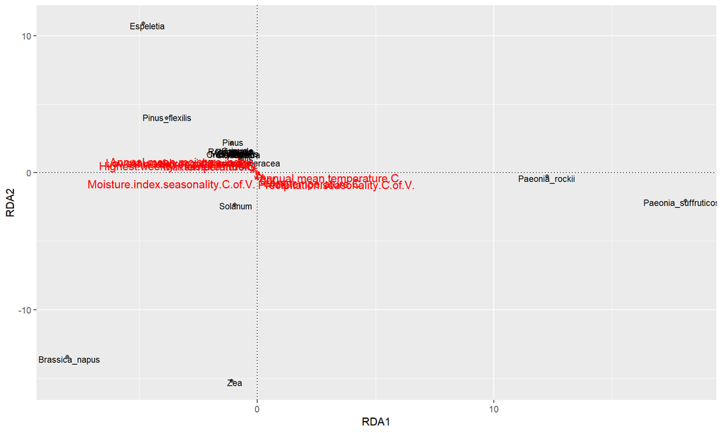

```r
smry <- summary(formulaRDA)
df1  <- data.frame(smry$sites[,1:2])       # RDA1 and RDA2 (for each quadrate)
df2  <- data.frame(smry$biplot[,1:2])     # loadings for RDA1 and RDA2 (for each variable)
rda.plot <- ggplot(df1, aes(x=RDA1, y=RDA2)) +
  geom_text(aes(label=rownames(df1)),size=3,position=position_jitter(width=.2,height=.2)) +
  geom_point(aes(alpha=0.3)) +
  geom_hline(yintercept=0, linetype="dotted") +
  geom_vline(xintercept=0, linetype="dotted")


(formulaRDA.PLOT<-rda.plot +
  geom_segment(data=df2, aes(x=0, xend=RDA1, y=0, yend=RDA2),
               color="red", arrow=arrow(length=unit(0.01,"npc"))) +
  geom_text(data=df2,
            aes(x=RDA1,y=RDA2,label=rownames(df2),
                hjust=0.5*(1-sign(RDA1)),vjust=0.5*(1-sign(RDA2))),
            color="red", size=4)+ theme(legend.position="none"))
```

## NMDS: unconstrained spatial analysis

So this is when the NMDS can be really helpful. You dont know what is playing a role in the OTU community assembly. Looking at them in space might give you a hint, or might inspire you.

### Calculate

We need to produce a betadiversity matrix again. We can keep the samples seperate now since we arent using climate here. We might be able to see on this if something else is happening.

```r
df<-data.frame(Species=OTU_table.t_species$Species)

M<-OTU_table.t
M$SampleID<-NULL
M$Species<-NULL
M$Species<-NULL


dist_M <- vegdist(M, method = "bray",binary=T)
```

```r
meta.nmds <- metaMDS(dist_M, k=2, trymax = 1000) # ok so k=2 means I want 2 dimensions
```

```
## *** Solution reached
```

```r
#data for plotting
##NMDS points
NMDS.data<-data.frame(Species=df$Species) # this is the only true difference from floristic composition analysis. Instead of using plots location and population, we want to visualize their species.
NMDS.data$NMDS1<-meta.nmds$points[ ,1]
NMDS.data$NMDS2<-meta.nmds$points[ ,2]
```

### Visualize

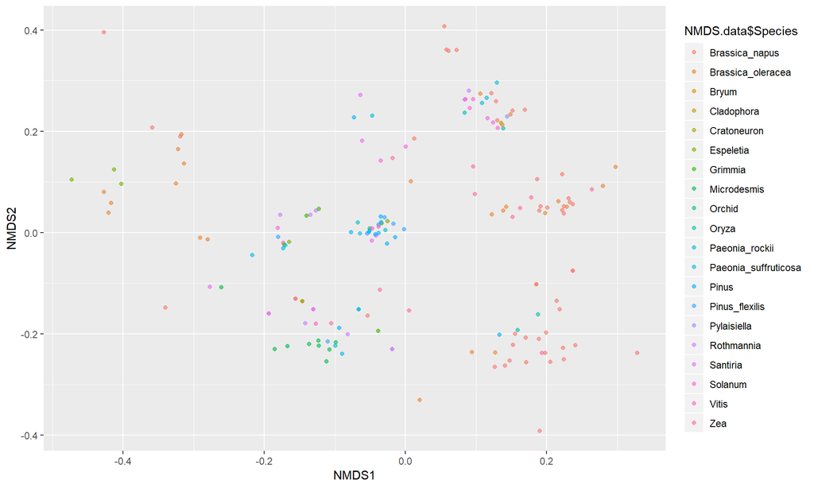

```r
ggplot(data = NMDS.data, aes(y = NMDS2, x = NMDS1))+
    geom_point( aes(col = NMDS.data$Species), size = 1.5,alpha=0.6)
```

They are not assembling because of climate… so what do you think might play into their assembly? This NMDS can help you think about it…